# Incubation_Analytics

Akin

October 14, 2016

## Fetching Data

```r
incubation <- read.csv("./incpreincideasubmissions/Incubation Application-report (Edited) (1).csv",
                       stringsAsFactors = FALSE)
```

## ANALYSIS OF INCUBATION

This report processes the submissions received from the incubation-idea submission. The various fieds collected are listed below:

```r
names(incubation)
```

```
##  [1] "X.ID"
##  [2] "What.market.challenge.are.you.addressing."
##  [3] "Why.are.you.addressing.this.particular.challenge."
##  [4] "Tell.us.about.your.solution"
##  [5] "Name.of.venture."
##  [6] "What.is.your.target.segment.and.indication.of.size."
##  [7] "How.is.your.solution.different.from.competition."
##  [8] "Launch.Pilot.date"
##  [9] "What.are.your.start.up.goals.for.the.next.6.12.months."
## [10] "What.is.your.most.pressing.need.as.a.start.up."
## [11] "How.much.do.you.need.over.the.next.six.months.to.grow."
## [12] "Link.to.launched.solution..web.or.mobile."
## [13] "Link.to.pitch.deck"
## [14] "About.the.team..names.and.roles.."
## [15] "How.long.has.the.team.been.working.on.this.solution."
## [16] "Why.is.the.team.best.suited.to.address.this.market.need."
## [17] "Current.location"
## [18] "Are.you.willing.to.move.to.Lagos.for.next.6.months."
## [19] "Start.Date..UTC."
## [20] "Submit.Date..UTC."
## [21] "Network.ID"
```

The report makes give some certain insights derivable from the data collected from the respondents

## Fetching Data

```r
incubation <- read.csv("./incpreincideasubmissions/Incubation Application-report (Edited) (1).csv",
                       stringsAsFactors = FALSE)
```

## Preprocessing

```r
incubation_edit <- unique(incubation)

#function to get the equivalent willingness
getwilling <- function(code){
  if (code == 1){
    return("willing")
  }
  else{
    return("notwilling")
  }
}

incubation_edit <- mutate(incubation, willingness= lapply(incubation$Are.you.willing.to.move.to.Lagos.for.next.6.months., getwilling))

#convert dates
incubation_edit <- mutate(incubation_edit,
                          applicationStart = as.Date(incubation_edit$Start.Date..UTC., "%m/%d/%Y %H:%M"),
                          applicationEnd = as.Date(incubation_edit$Submit.Date..UTC., "%m/%d/%Y %H:%M"))

#get the time taken to fill the form
formFilling <- vector()
for (i in seq(length(incubation_edit$Submit.Date..UTC.))){
  timediff <- difftime(incubation_edit$applicationEnd[i], incubation_edit$applicationStart[i], units = "days")
  timediff <- as.numeric(timediff)
  formFilling <- c(formFilling, timediff)

}
incubation_edit <- mutate(incubation_edit, formFillingTime= formFilling)

incubation_edit <- mutate(incubation_edit, submissionMonth = months(incubation_edit$applicationEnd, abbreviate = T))
incubation_edit <- mutate(incubation_edit, willingness= as.character(incubation_edit$willingness))

#improve on location
incubation_edit <- mutate(incubation_edit,
                          location= paste(incubation_edit$Current.location,
                                          "Nigeria"))
```

## Showing the Visuals

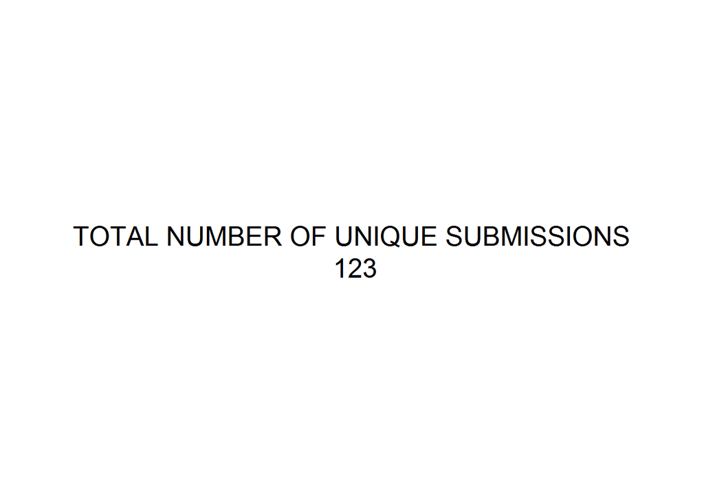

```r
par(mar = c(0,0,0,0))
plot(c(0, 1), c(0, 1), ann = F,
     bty = 'n', type = 'n', xaxt = 'n', yaxt = 'n')

text(x=0.5, y=0.5, paste("TOTAL NUMBER OF UNIQUE SUBMISSIONS\n",
                          as.character(nrow(incubation_edit))),
     cex = 1.6, col = "black")
```

We had an almost neglible number of persons unwilling to come to Lagos of the total number of idea submissions. This is obvious from the plot below derived from a yes or no response as given by the `Are.you.willing.to.move.to.Lagos.for.next.6.months.`

## Willingness to Come to Lagos

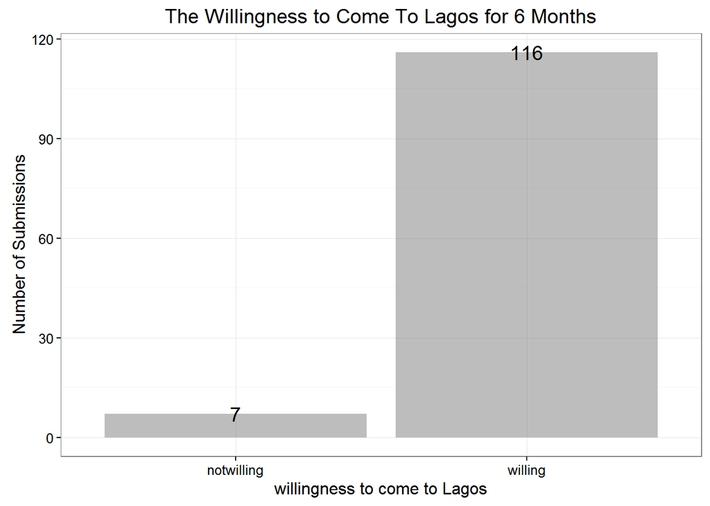

```r
#willingness to come
will <- as.data.frame(table(incubation_edit$willingness,
                                   dnn = c("willingness")))

ggplot(will, aes(will$willingness,
                        will$Freq))+geom_bar(stat = "identity",
                                                    #col = "red",
                                                    #fill = "blue",
                                                    alpha = 0.4)+labs(x =
      "willingness to come to Lagos", y = "Number of Submissions")+ggtitle(
        "The Willingness to Come To Lagos for 6 Months")+geom_text(
          aes(label = Freq), size = 5, vjust= "middle")+theme_bw()
```

The following visualisation helps to show this distribution. The response to the `Current.location` field has been used to generate reasonably approximate locations for the plotted points. The deeper blue colours signifies more submissions from a given location

## Locations

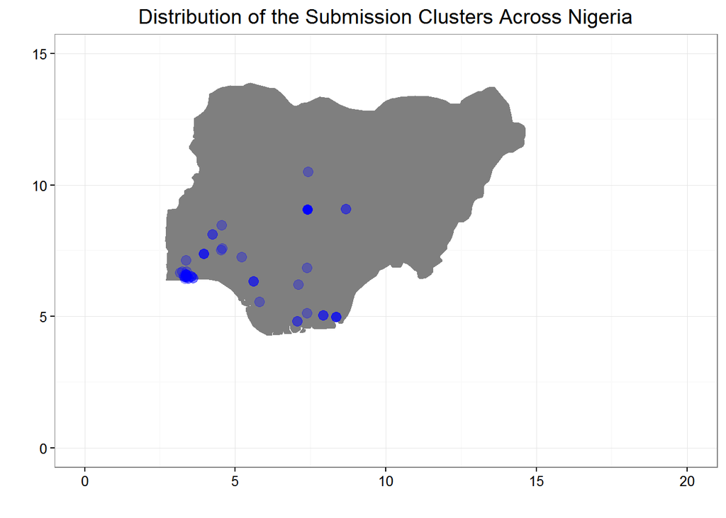

```r
#loc <- incubation_edit$location
#loc.code <- geocode(location = loc)

loc.code <- read.csv("./incubation_locations.csv", stringsAsFactors = F)
mp <- NULL
mapWorld <- borders("world", regions = "Nigeria", colour="gray50", fill="gray50") # create a layer of borders
mp <- ggplot() +   mapWorld

#Now Layer the cities on top
mp <- mp+ geom_point(aes(x=loc.code$lon, y=loc.code$lat) ,color="blue", size=3, alpha= 0.3)
mp + coord_cartesian(ylim = c(0,15), xlim = c(0, 20))+labs(x= "",
                                                           y= "", title= "Distribution of the Submission Clusters Across Nigeria")+theme_bw()
```

## Moving Forward

Effort is still being made to deriv more information on the data. However, the following are my recommendations:

- I will suggest that more variables be collected, such as;
- Age
- level of Education

These will further help gain insights into the idea submission as well as the individuals, providing us with potentially useful information on the distribution of respondents

- Also the use of categorical variables where applicable will ease classification